# CodingChallenge4

Kylie Blake

2025-02-27

# Coding Challenge 4

## Question 2 - Source Manuscript

1. *At the top of the document, make a clickable link to the manuscript where these data are published.*

[Noel, Z.A., Roze, L.V., Breunig, M., Trail, F. 2022. Endophytic fungi as promising biocontrol agent to protect wheat from Fusarium graminearum head blight. Plant Disease. https://doi.org/10.1094/PDIS-06-21-1253-RE](https://doi.org/10.1094/PDIS-06-21-1253-RE)

## Question 1

*Define the following:*

- **YAML header** is a section of text at the top of an Rmarkdown file that gives info about the title, author, and date of the Rmd file, but the output section also determines the final file format, such as an HTML, word, or PDF document.
- **Literate programming** in R markdown files is the concept of combining R code with natural language, such as English. This allows the user to explain how their code works in a common language, while also executing code chunks.

## Question 2 (b&c)

*Take the code you wrote for coding challenge 3, question 5, and incorporate it into your R markdown file. Some of you have already been doing this, which is great! Your final R markdown file should have the following elements.*

2. *Read the data using a relative file path with na.strings option set to “na”. This means you need to put the Mycotoxin.csv file we have used for the past two weeks into your directory, which git tracks.*
3. *Make a separate code chunk for the figures plotting the DON data, 15ADON, and Seedmass, and one for the three combined using ggarrange.*

```r
#Calling in packages
library(ggplot2)
library(ggpubr)
library(ggrepel)
library(tinytex)
library(knitr)
library(rmarkdown)
library(pandoc)
#Question 2. Part a. Calling in Dataset
MycotoxinData <- read.csv("MycotoxinData.csv",na.strings="na")

#Call in Color Blind Palette for ggplot
cbbPalette <- c("#E69F00", "#56B4E9", "#009E73", "#F0E442", "#0072B2", "#D55E00", "#CC79A7","#000000")
```

### Plotting DON x Treatment

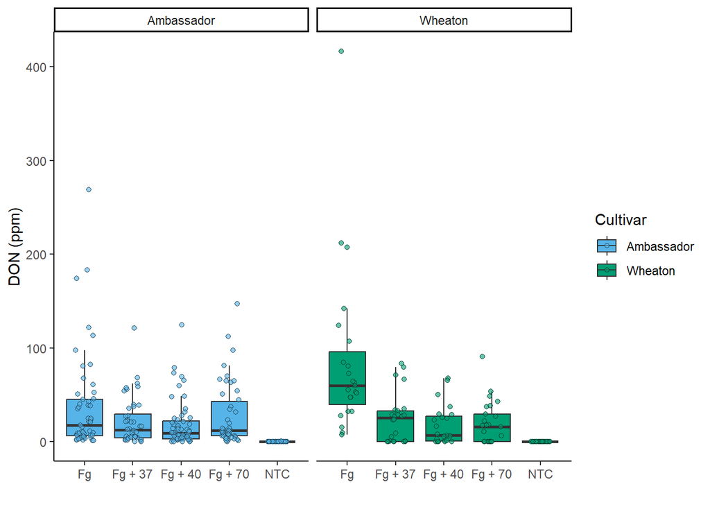

```r
DON <- ggplot(MycotoxinData, aes(x=Treatment, y=DON, fill=Cultivar)) +
  geom_boxplot(outlier.shape=NA) +
  geom_point(position = position_jitterdodge(dodge.width=0.9), shape=21,alpha=0.6)+ #jitter dodge points and make them transparent
  scale_fill_manual(values = c(cbbPalette[[2]],cbbPalette[[3]]))+ #manually insert two colors from CbbPalette
  xlab("")+ #label x-axis
  ylab("DON (ppm)")+ #label y-axis
  theme_classic() + #classic theme
  facet_wrap(~Cultivar) #facet by Cultivar
DON
```

### Plotting X15ADON x Treatment

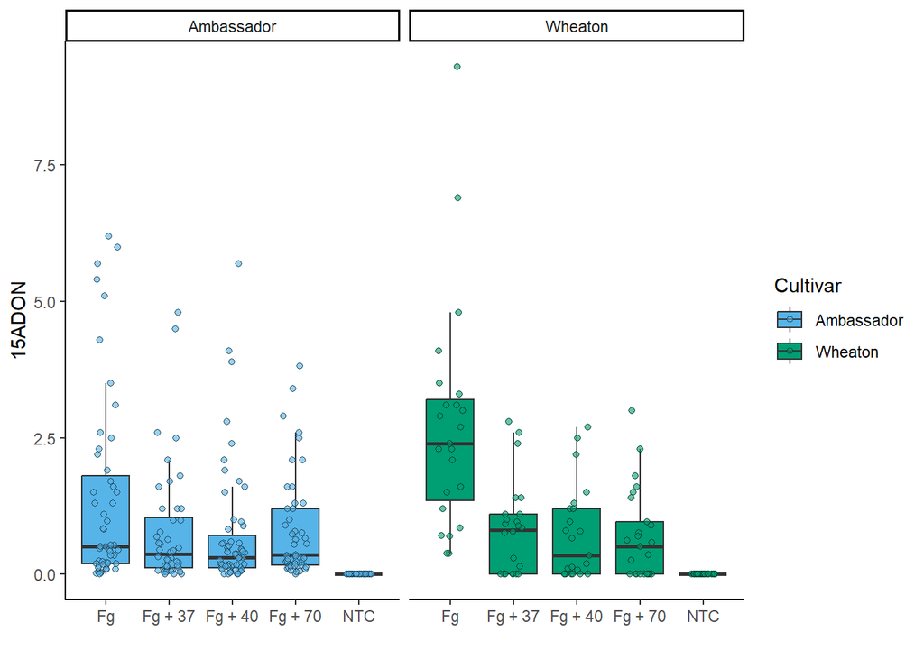

```r
X15ADON <- ggplot(MycotoxinData, aes(x=Treatment, y=X15ADON, fill=Cultivar)) +
  geom_boxplot(outlier.shape=NA) +
  geom_point(position = position_jitterdodge(dodge.width=0.9), shape=21,alpha=0.6)+ #jitter dodge points and make them transparent
  scale_fill_manual(values = c(cbbPalette[[2]],cbbPalette[[3]]))+ #manually insert two colors from CbbPalette
  xlab("")+ #label x-axis
  ylab("15ADON")+ #label y-axis
  theme_classic() + #classic theme
  facet_wrap(~Cultivar) #facet by Cultivar
X15ADON
```

### Plotting MassperSeed_mg x Treatment

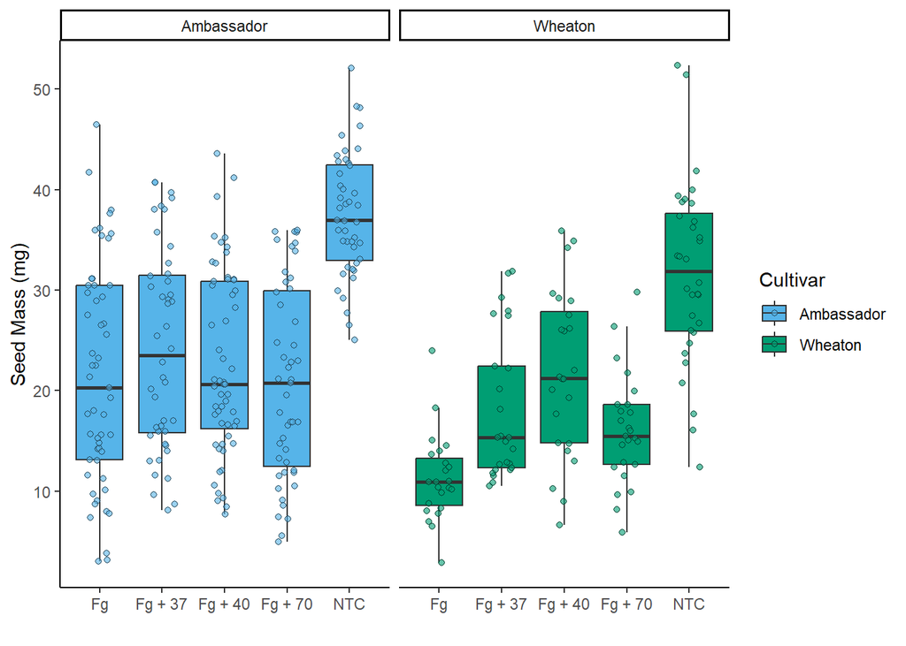

```r
MassperSeed <- ggplot(MycotoxinData, aes(x=Treatment, y=MassperSeed_mg, fill=Cultivar)) +
  geom_boxplot(outlier.shape=NA) +
  geom_point(position = position_jitterdodge(dodge.width=0.9), shape=21,alpha=0.6)+ #jitter dodge points and make them transparent
  scale_fill_manual(values = c(cbbPalette[[2]],cbbPalette[[3]]))+ #manually insert two colors from CbbPalette
  xlab("")+ #label x-axis
  ylab("Seed Mass (mg)")+ #label y-axis
  theme_classic() + #classic theme
  facet_wrap(~Cultivar) #facet by Cultivar
MassperSeed
```

### Statistical Tests and Final Figure

*Use geom_pwc() to add t.test pairwise comparisons to the three plots made above. Combine three figures into group via ggarrange*

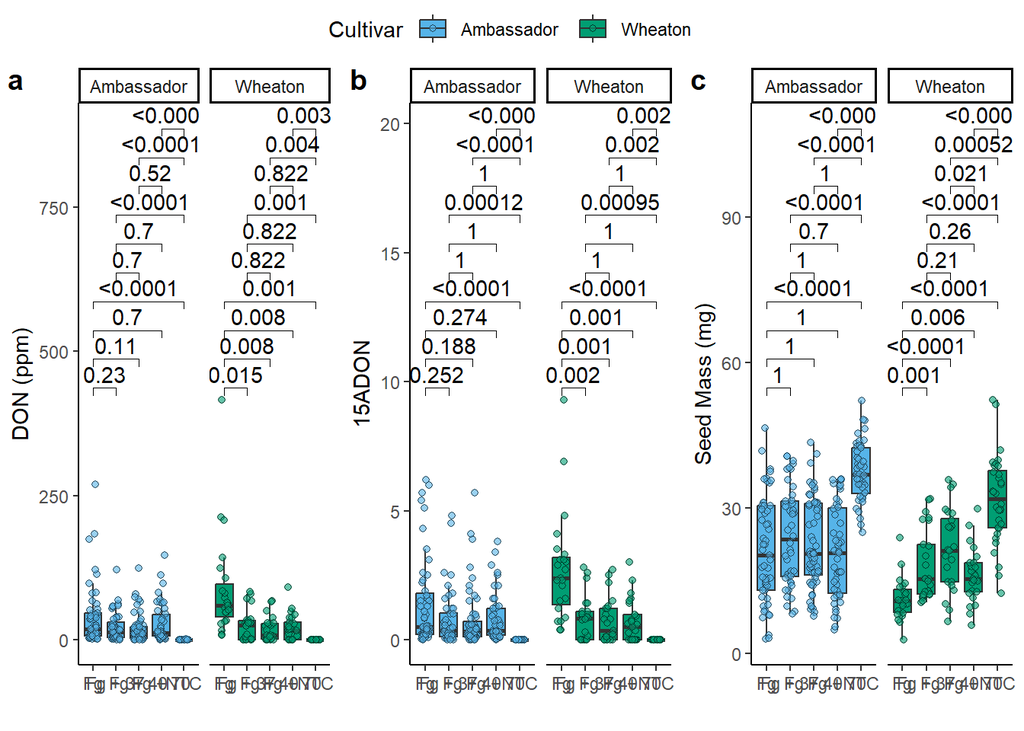

```r
#Calculating t-tests for the three figures
Stat1 <-  DON +
  geom_pwc(aes(group=Treatment), method = "t_test",label = "p.adj.format") #Adding t-test to Question 1 figure

Stat2 <- X15ADON +
  geom_pwc(aes(group=Treatment),method = "t_test",label = "p.adj.format")  #Adding t-test to Question 2 figure

Stat3 <- MassperSeed +
  geom_pwc(aes(group=Treatment),method = "t_test",label = "p.adj.format")  #Adding t-test to Question 3 figure

#Plotting three figures with t-test calculations
figure1 <- ggarrange(
  Stat1,  # First plot: water.imbibed
  Stat2,  # Second plot: bac.even
  Stat3,  # Third plot: water.imbibed.cor
  labels = "auto",  # Automatically label the plots (A, B, C, etc.)
  nrow = 1,  # Arrange the plots in 3 rows
  ncol = 3,  # Arrange the plots in 1 column
  common.legend = TRUE  # Do not include a legend in the combined figure
)
figure1
```

## Question 3

*Knit your document together in the following formats:* a. *.docx (word document) OR .pdf with a table of contents* b. *GitHub flavored markdown (.md file).*

This document is knitted as a PDF file and GitHub flavored markdown file as seen in the output in the YAML header.

## Question 4

*Push the .docx or .pdf and .md files to GitHub inside a directory called Coding Challenge 4.*

The Coding Challenge 4 file now lives in my GitHub with a .pdf and .md version of this document. The link will be provided in Question 6.

## Question 5

*Now edit, commit, and push the README file for your repository and include the following elements.* a. *A clickable link in your README to your GitHub flavored .md file* b. *A file tree of your GitHub repository.*

The README file now lives in my PLPA6820 repository with a clickable link to the .md version of this assignment and a file tree of my PLPA6820 repository.

## Question 6

*Please provide me a clickable link to your GitHub*

[**Link to my Github**](https://github.com/kzb0180/PLPA6820)

**Note:** I have my repository saved as private. I have added you as a collaborator.When I tried this link it didn’t work, but it is correct. Here is the link typed out as well: https://github.com/kzb0180/PLPA6820